# LGT Simulation Study

Laura Kubatko, Simone Linz, Kristina Wicke

2026-06-13

This document reproduces the simulation study in the manuscript “Revisiting a simple model of lateral gene transfer in phylogenetics” by Laura Kubatko, Simone Linz, and Kristina Wicke.

We set the initial seed here, so that the results presented in the manuscript can be reproduced exactly. If you would like to repeat the simulation study with a different set of randomly generated data, you need only change the seed in the chunk below.

```r
set.seed(65023)
```

### Part 1: Distribution of MLEs

We first consider estimating the MLEs of the parameters $(t_1, t_2, \lambda)$. We simulate repeatedly from the model with fixed parameter values, obtain MLEs, and plot the distribution of the MLEs using the code below.

```r
# compute site pattern probabilities for a specific choice of parameters
# species tree is ((A:t1,B:t1):t2-t1,C:t2)
# m is mu in the JC69 model
# lambda is the HGT rate parameter

GetSitePatternProbs = function(t1,t2,m,lambda) {

pxxx = (3*exp(-((t1+2*t2)*(m+lambda)))*m*(m-2*lambda) + 4*m*lambda +     3*exp(-3*t1*(m+lambda))*m*lambda + 8*lambda^2 -
6*exp(-t1*lambda-2*t2*(m+lambda))*m*(m+lambda) +
9*exp(-2*t2*(m+lambda))*m*(m+2*lambda) + m^3/(2*m+3*lambda) +
(3*exp(-2*m*t1-3*t1*lambda)*m*(m+lambda)*(m+3*lambda))/(2*m+3*lambda))/(8*(m+lambda)^2)

pxxy = 1/(16*((m+lambda)^2)*(2*m+3*lambda))*3*(2*m*(m+2*lambda)^2 +
 exp(-(3*t1+2*t2)*(m+lambda))*(2*exp(3*t1*(m+lambda))*m*(m-2*lambda)*(2*m+3*lambda) -
 2*exp(2*t1*(m+lambda))*m*(2*m-lambda)*(2*m+3*lambda) +
 2*exp(3*m*t1+2*t1*lambda)*m*(m+lambda)*(2*m+3*lambda) +
 exp(3*m*t1+2*m*t2+2*t2*lambda)*((m+lambda)^2)*(2*m+3*lambda) -
 2*exp(2*t2*(m+lambda))*lambda*(2*m+lambda)*(2*m+3*lambda) +
 exp(m*t1+2*m*t2+2*t2*lambda)*(-4*m^3-7*(m^2)*lambda+3*lambda^3)))

pxyy = 1/(32*((m+lambda)^2)*(2*m+3*lambda))*3*(4*m*(m+2*lambda)^2 -
 exp(-(3*t1+2*t2)*(m+lambda))*(2*exp(2*t1*(m+lambda))*m*(m-5*lambda)*(2*m+3*lambda) -
 4*exp(3*t1*(m+lambda))*m*(m-2*lambda)*(2*m+3*lambda) +
 2*exp(2*t2*(m+lambda))*(m-lambda)*lambda*(2*m+3*lambda) +
 6*exp(3*m*t1+2*t1*lambda)*m*(m+lambda)*(2*m+3*lambda) +
 exp(3*m*t1+2*m*t2+2*t2*lambda)*((m+lambda)^2)*(2*m+3*lambda) -
 3*exp(m*t1+2*m*t2+2*t2*lambda)*(m+lambda)*(2*m^2+3*m*lambda-lambda^2)))

pxyz = 3*m*(-3*exp(-2*t2*(m+lambda))*m +
 exp(-(t1+2*t2)*(m+lambda))*(m-2*lambda) +
 exp(-3*t1*(m+lambda))*lambda +
 2*exp(-t1*lambda-2*t2*(m+lambda))*(m+lambda) +
 m*(m+2*lambda)/(2*m+3*lambda) -
 (exp(t1*(m-3*(m+lambda)))*(m+lambda)*(m+3*lambda)/(2*m+3*lambda)))/(4*(m+lambda)^2)

return(c(pxxx,pxxy,pxyy,pxyz))

}
```

As noted in the manuscript, we use transformations similar to those developed by Dave Swofford in the supplement to Peng et al. (2022). Specifically, the parameter vector is
$$z_1
= sin^{-1}\biggl(\sqrt{\frac{t_1}{t_2}}\biggr)$$
$$z_2 = \log (t_2)$$
$$z_3 = \log(\lambda)$$

The parameters are back-transformed prior to likelihood calculation (in the function that computes the likelihood) according to

```r
GetLikFull = function(x,data) {

  t2 = exp(x[2])
  t1 = t2*(sin(x[1]))^2
  lambda = exp(x[3])
  probs = GetSitePatternProbs(t1,t2,4/3,lambda)

  # note that prob3 is used twice; probs is of dimension 4
  lik = data[1]*log(probs[1])+data[2]*log(probs[2])+data[3]*log(probs[3])+
        data[4]*log(probs[3])+data[5]*log(probs[4])

  return(-1.0*lik)

}
```

The code below creates functions to run the simulation study for various choices of $t_1, t_2, \lambda$ and sample size (number of sites in the aligned data).

```r
RunSim = function(myt1,myt2,mylambda,mysamsize) {

  myests = matrix(0,ncol=3,nrow=100)
  xx = c(asin(sqrt(myt1/myt2)),log(myt2),log(mylambda))

  for (i in 1:100) {

    # Get true site pattern probabilities
    myprobs = GetSitePatternProbs(myt1,myt2,4/3,mylambda)
    myprobs_full = c(myprobs[1],myprobs[2],myprobs[3],myprobs[3],myprobs[4])

    # Get a sample of site patterns
    mydat = rmultinom(1,mysamsize,myprobs_full)
    est = optim(par=xx,fn=GetLikFull,data=mydat)
    myests[i,2] = exp(est$par[2])
    myests[i,1] = exp(est$par[2])*(sin(est$par[1]))^2
    myests[i,3] = exp(est$par[3])

  }

  return(myests)

}


PlotResults = function(myests,myt1,myt2,mylambda) {
  par(mfrow=c(1,3))
  hist(myests[,1],xlab=expression(t[1]),main="",col="maroon",cex.axis=1.5,cex.lab=1.5)
  lines(c(myt1,myt1),c(0,100),col="black",lwd=4)
  lines(c(mean(myests[,1]),mean(myests[,1])),c(0,100),col="darkgray",lwd=3)
  hist(myests[,2],xlab=expression(t[2]),main="",col="maroon",cex.axis=1.5,cex.lab=1.5)
  lines(c(myt2,myt2),c(0,100),col="black",lwd=4)
  lines(c(mean(myests[,2]),mean(myests[,2])),c(0,100),col="darkgray",lwd=3)
  hist(myests[,3],xlab=expression(lambda),main="",col="maroon",cex.axis=1.5,cex.lab=1.5)
  lines(c(mylambda,mylambda),c(0,100),col="black",lwd=4)
  lines(c(mean(myests[,3]),mean(myests[,3])),c(0,100),col="darkgray",lwd=3)

}
```

Now we run the simulation study and plot the results. The following settings are considered:

**Setting 1:** $t_1 = 0.1, t_2 = 0.2, \lambda=0.8$  
**Setting 2:** $t_1 = 0.2, t_2 = 0.4, \lambda=0.8$  
**Setting 3:** $t_1 = 0.4, t_2 = 0.8, \lambda=0.8$  
**Setting 4:** $t_1 = 0.1, t_2 = 0.2, \lambda=1.2$  
**Setting 5:** $t_1 = 0.2, t_2 = 0.4, \lambda=1.2$  
**Setting 6:** $t_1 = 0.4, t_2 = 0.8, \lambda=1.2$

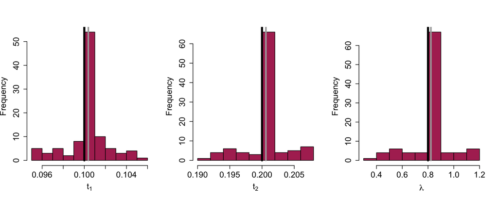

```r
ests1 = RunSim(0.1,0.2,0.8,1000000)
PlotResults(ests1,0.1,0.2,0.8)
```

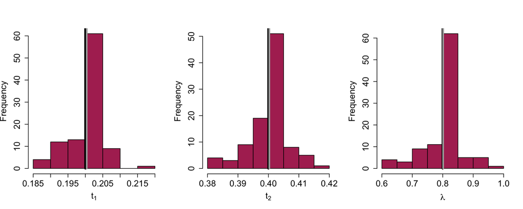

```r
ests2 = RunSim(0.2,0.4,0.8,1000000)
PlotResults(ests2,0.2,0.4,0.8)
```

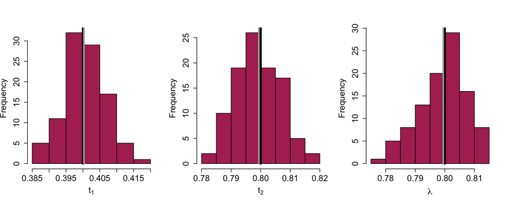

```r
ests3 = RunSim(0.4,0.8,0.8,1000000)
PlotResults(ests3,0.4,0.8,0.8)
```

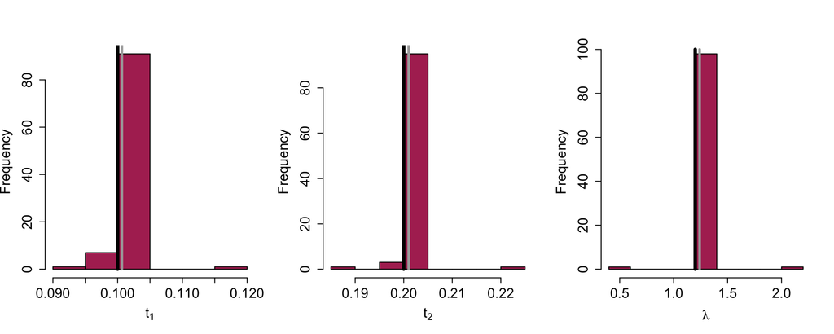

```r
ests4 = RunSim(0.1,0.2,1.2,1000000)
PlotResults(ests4,0.1,0.2,1.2)
```

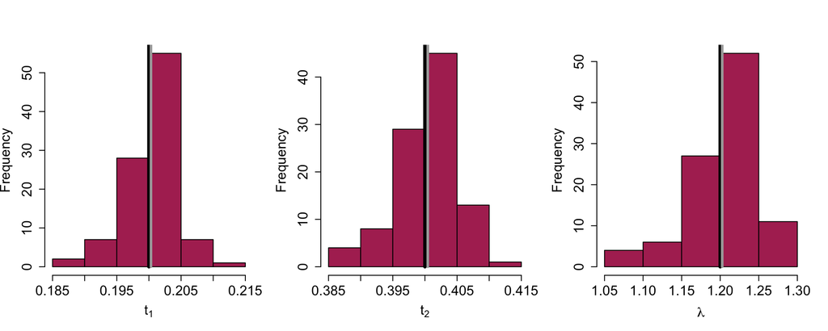

```r
ests5 = RunSim(0.2,0.4,1.2,1000000)
PlotResults(ests5,0.2,0.4,1.2)
```

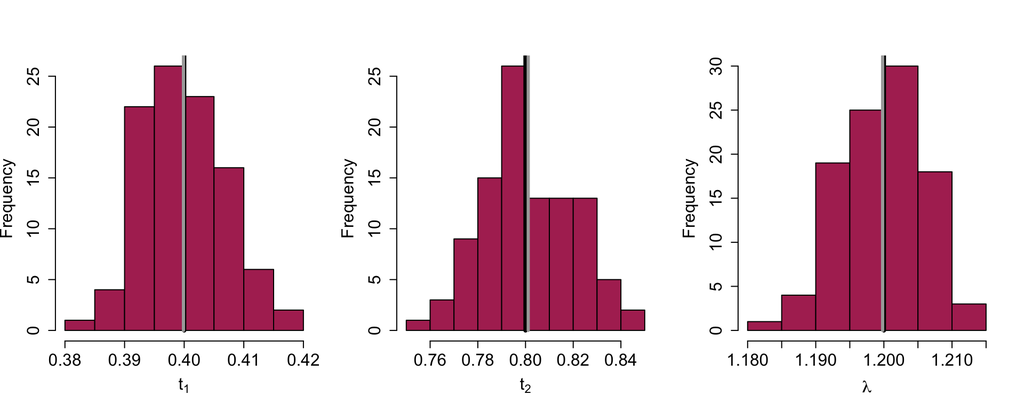

```r
ests6 = RunSim(0.4,0.8,1.2,1000000)
PlotResults(ests6,0.4,0.8,1.2)
```

### Part 2: Mean squared error as a function of sample size

The code below provides functions for the simulation so that we can look at how estimation error, as measured by the Root Mean Squared Error (RMSE), changes as a function of parameter values and sample size.

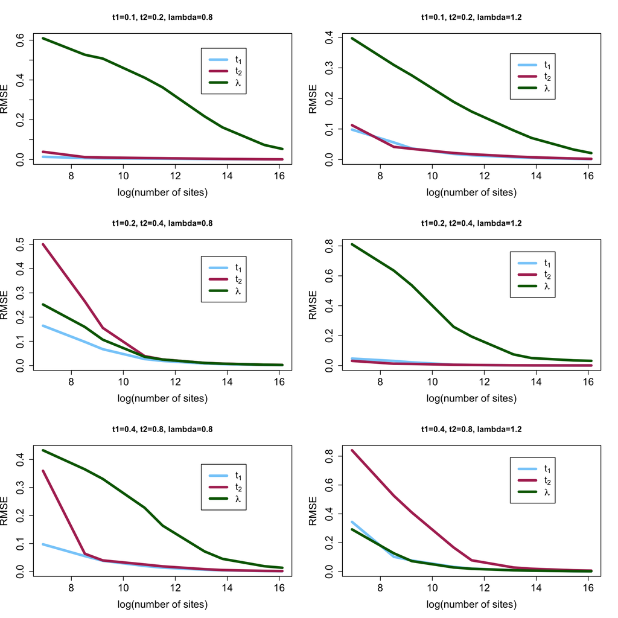

```r
# Function to run the simulation study (1000 reps)
# and return the rmse for the three parameters

RunSimMSE = function(myt1,myt2,mylambda,nsites) {

  mysimests = matrix(0,ncol=3,nrow=1000)
  xxx = c(asin(sqrt(myt1/myt2)),log(myt2),log(mylambda))

  for (i in 1:1000) {

    # Get true site pattern probabilities
    myprobs = GetSitePatternProbs(myt1,myt2,4/3,mylambda)
    myprobs_full = c(myprobs[1],myprobs[2],myprobs[3],myprobs[3],myprobs[4])

    # Get a sample of site patterns
    mydata = rmultinom(1,nsites,myprobs_full)
    #print(mydata)
    est = optim(par=xxx,fn=GetLikFull,data=mydata)
    #print(est)
    mysimests[i,2] = exp(est$par[2])
    mysimests[i,1] = exp(est$par[2])*(sin(est$par[1]))^2
    mysimests[i,3] = exp(est$par[3])

  }

  return(c(sqrt(mean((mysimests[,1]-myt1)^2)),sqrt(mean((mysimests[,2]-myt2)^2)),sqrt(mean((mysimests[,3]-mylambda)^2))))

}


# Now run a simulation study where we look at RMSE for various
# choices of sample size

rmse5 = matrix(c(c(RunSimMSE(0.2,0.4,1.2,1000)),
c(RunSimMSE(0.2,0.4,1.2,5000)),
c(RunSimMSE(0.2,0.4,1.2,10000)),
c(RunSimMSE(0.2,0.4,1.2,50000)),
c(RunSimMSE(0.2,0.4,1.2,100000)),
c(RunSimMSE(0.2,0.4,1.2,500000)),
c(RunSimMSE(0.2,0.4,1.2,1000000)),
c(RunSimMSE(0.2,0.4,1.2,5000000)),
c(RunSimMSE(0.2,0.4,1.2,10000000))),ncol=3,byrow=T)

rmse2 = matrix(c(c(RunSimMSE(0.2,0.4,0.8,1000)),
c(RunSimMSE(0.2,0.4,0.8,5000)),
c(RunSimMSE(0.2,0.4,0.8,10000)),
c(RunSimMSE(0.2,0.4,0.8,50000)),
c(RunSimMSE(0.2,0.4,0.8,100000)),
c(RunSimMSE(0.2,0.4,0.8,500000)),
c(RunSimMSE(0.2,0.4,0.8,1000000)),
c(RunSimMSE(0.2,0.4,0.8,5000000)),
c(RunSimMSE(0.2,0.4,0.8,10000000))),ncol=3,byrow=T)

rmse4 = matrix(c(c(RunSimMSE(0.1,0.2,1.2,1000)),
c(RunSimMSE(0.1,0.2,1.2,5000)),
c(RunSimMSE(0.1,0.2,1.2,10000)),
c(RunSimMSE(0.1,0.2,1.2,50000)),
c(RunSimMSE(0.1,0.2,1.2,100000)),
c(RunSimMSE(0.1,0.2,1.2,500000)),
c(RunSimMSE(0.1,0.2,1.2,1000000)),
c(RunSimMSE(0.1,0.2,1.2,5000000)),
c(RunSimMSE(0.1,0.2,1.2,10000000))),ncol=3,byrow=T)

rmse1 = matrix(c(c(RunSimMSE(0.1,0.2,0.8,1000)),
c(RunSimMSE(0.1,0.2,0.8,5000)),
c(RunSimMSE(0.1,0.2,0.8,10000)),
c(RunSimMSE(0.1,0.2,0.8,50000)),
c(RunSimMSE(0.1,0.2,0.8,100000)),
c(RunSimMSE(0.1,0.2,0.8,500000)),
c(RunSimMSE(0.1,0.2,0.8,1000000)),
c(RunSimMSE(0.1,0.2,0.8,5000000)),
c(RunSimMSE(0.1,0.2,0.8,10000000))),ncol=3,byrow=T)

rmse6 = matrix(c(c(RunSimMSE(0.4,0.8,1.2,1000)),
c(RunSimMSE(0.4,0.8,1.2,5000)),
c(RunSimMSE(0.4,0.8,1.2,10000)),
c(RunSimMSE(0.4,0.8,1.2,50000)),
c(RunSimMSE(0.4,0.8,1.2,100000)),
c(RunSimMSE(0.4,0.8,1.2,500000)),
c(RunSimMSE(0.4,0.8,1.2,1000000)),
c(RunSimMSE(0.4,0.8,1.2,5000000)),
c(RunSimMSE(0.4,0.8,1.2,10000000))),ncol=3,byrow=T)

rmse3 = matrix(c(c(RunSimMSE(0.4,0.8,0.8,1000)),
c(RunSimMSE(0.4,0.8,0.8,5000)),
c(RunSimMSE(0.4,0.8,0.8,10000)),
c(RunSimMSE(0.4,0.8,0.8,50000)),
c(RunSimMSE(0.4,0.8,0.8,100000)),
c(RunSimMSE(0.4,0.8,0.8,500000)),
c(RunSimMSE(0.4,0.8,0.8,1000000)),
c(RunSimMSE(0.4,0.8,0.8,5000000)),
c(RunSimMSE(0.4,0.8,0.8,10000000))),ncol=3,byrow=T)

xvals = c(1000,5000,10000,50000,100000,500000,1000000,5000000,10000000)

par(mfrow=c(3,2))

plot(log(xvals),rmse1[,1],type='l',xlab="log(number of sites)",ylab="RMSE",ylim=c(0,max(rmse1)),col="lightskyblue",lwd=4,main="t1=0.1, t2=0.2, lambda=0.8",cex.axis=1.5,cex.lab=1.5)
lines(log(xvals),rmse1[,2],col="maroon",lwd=4)
lines(log(xvals),rmse1[,3],col="darkgreen",lwd=4)
legend(13,max(rmse1)-0.05,legend=c(expression(t[1]),expression(t[2]),expression(lambda)),col=c("lightskyblue","maroon","darkgreen"),lwd=c(4,4,4),cex=1.4)

plot(log(xvals),rmse2[,1],type='l',xlab="log(number of sites)",ylab="RMSE",ylim=c(0,max(rmse2)),col="lightskyblue",lwd=4,main="t1=0.1, t2=0.2, lambda=1.2",cex.axis=1.5,cex.lab=1.5)
lines(log(xvals),rmse2[,2],col="maroon",lwd=4)
lines(log(xvals),rmse2[,3],col="darkgreen",lwd=4)
legend(13,max(rmse2)-0.05,legend=c(expression(t[1]),expression(t[2]),expression(lambda)),col=c("lightskyblue","maroon","darkgreen"),lwd=c(4,4,4),cex=1.4)

plot(log(xvals),rmse3[,1],type='l',xlab="log(number of sites)",ylab="RMSE",ylim=c(0,max(rmse3)),col="lightskyblue",lwd=4,main="t1=0.2, t2=0.4, lambda=0.8",cex.axis=1.5,cex.lab=1.5)
lines(log(xvals),rmse3[,2],col="maroon",lwd=4)
lines(log(xvals),rmse3[,3],col="darkgreen",lwd=4)
legend(13,max(rmse3)-0.05,legend=c(expression(t[1]),expression(t[2]),expression(lambda)),col=c("lightskyblue","maroon","darkgreen"),lwd=c(4,4,4),cex=1.4)

plot(log(xvals),rmse4[,1],type='l',xlab="log(number of sites)",ylab="RMSE",ylim=c(0,max(rmse4)),col="lightskyblue",lwd=4,main="t1=0.2, t2=0.4, lambda=1.2",cex.axis=1.5,cex.lab=1.5)
lines(log(xvals),rmse4[,2],col="maroon",lwd=4)
lines(log(xvals),rmse4[,3],col="darkgreen",lwd=4)
legend(13,max(rmse4)-0.05,legend=c(expression(t[1]),expression(t[2]),expression(lambda)),col=c("lightskyblue","maroon","darkgreen"),lwd=c(4,4,4),cex=1.4)

plot(log(xvals),rmse5[,1],type='l',xlab="log(number of sites)",ylab="RMSE",ylim=c(0,max(rmse5)),col="lightskyblue",lwd=4,main="t1=0.4, t2=0.8, lambda=0.8",cex.axis=1.5,cex.lab=1.5)
lines(log(xvals),rmse5[,2],col="maroon",lwd=4)
lines(log(xvals),rmse5[,3],col="darkgreen",lwd=4)
legend(13,max(rmse5)-0.05,legend=c(expression(t[1]),expression(t[2]),expression(lambda)),col=c("lightskyblue","maroon","darkgreen"),lwd=c(4,4,4),cex=1.4)

plot(log(xvals),rmse6[,1],type='l',xlab="log(number of sites)",ylab="RMSE",ylim=c(0,max(rmse6)),col="lightskyblue",lwd=4,main="t1=0.4, t2=0.8, lambda=1.2",cex.axis=1.5,cex.lab=1.5)
lines(log(xvals),rmse6[,2],col="maroon",lwd=4)
lines(log(xvals),rmse6[,3],col="darkgreen",lwd=4)
legend(13,max(rmse6)-0.05,legend=c(expression(t[1]),expression(t[2]),expression(lambda)),col=c("lightskyblue","maroon","darkgreen"),lwd=c(4,4,4),cex=1.4)
```